# Exploratory Analysis

## Intro

Our domain of interest is student loans. Specifically, we are looking at a dataset on Title IV Federal student loans. The dataset comes from the government and lists every university that received federal student loans, as well as numeric information on amount given and how many people received loans.The datasey we have is only for quarter 1 of 2020, although there are similar datasets available for many years in the past.

## Summary Info

In our dataset, we found that the university with the highest amount of subsidized loan recipients is ARIZONA STATE UNIVERSITY. The average amount of subsidized recipients across all colleges is 660. The total amount of colleges represented in the dataset is 4274. We also found that the average amount of money going to each college in subsidized loans is 1.351416^{6} and that the highest amount given out to one college is 5.9581527^{7}.

## Table

The table that we wanted to highlight contains a list of schools in each state that has the highest ratio of disimbursement money to originated loan money. This is significant because we might want to attend the school that disimburses a large amount of money instead of little amounts. The ratio is just one way to visualize how much money is disimbursed at a time by that school. For example, a ratio of 1.00 means that it the school reimburses the funds fully at a time, but only once in, say, a year, while a ratio of 0.50 means that the school reimburses 50% of the total fund in one disimbursement, and this usually means that the school does more disimbursements in one year in smaller amounts compared to the schools with higher ratios. This might be useful to someone who has a preference in their money management. People who like to manage a large sum of money should go for schools with a higher ratio, while people who are more comfortable with “annual income” should pick schools with lower ratio values.

| School | State | Subsidized Disimbursement Ratio |
| --- | --- | --- |
| UNIVERSITY OF SOUTHERN CALIFORNIA | CA | 1.0000000 |
| GOLDEY-BEACOM COLLEGE | DE | 0.5503265 |
| AMERICAN UNIVERSITY | DC | 0.5232216 |
| FLORIDA STATE UNIVERSITY | FL | 1.0000000 |
| NOVA SOUTHEASTERN UNIVERSITY-DAVIE | FL | 1.0000000 |
| UNIVERSITY OF SOUTH FLORIDA | FL | 1.0000000 |
| CALUMET COLLEGE OF SAINT JOSEPH | IN | 1.0000000 |
| UNIVERSITY OF IOWA | IA | 1.0000000 |
| BEREA COLLEGE | KY | 0.8649895 |
| BOWDOIN COLLEGE | ME | 1.0000000 |
| HAGERSTOWN COMMUNITY COLLEGE | MD | 1.0000000 |
| HELLENIC COLLEGE & HOLY CROSS GREEK ORTHODOX SCHOOL OF THEOLOGY | MA | 1.0000000 |
| QUINSIGAMOND COMMUNITY COLLEGE | MA | 1.0000000 |
| SACRED HEART MAJOR SEMINARY | MI | 1.0000000 |
| WOFFORD COLLEGE | SC | 1.0000000 |
| NORTHERN STATE UNIVERSITY | SD | 0.5244797 |
| SOUTHWESTERN ASSEMBLIES OF GOD UNIVERSITY | TX | 1.0000000 |
| UNIVERSITY OF THE VIRGIN ISLANDS | VI | 0.4995206 |
| SAN FRANCISCO ART INSTITUTE | CA | 1.0000000 |
| UNIVERSITY OF CENTRAL FLORIDA-MAIN CAMPUS | FL | 1.0000000 |
| GRATZ COLLEGE | PA | 1.0000000 |
| METHODIST COLLEGE | IL | 1.0000000 |
| COVENANT SCHOOL OF NURSING AND ALLIED HEALTH | TX | 1.0000000 |
| DYERSBURG STATE COMMUNITY COLLEGE | TN | 0.6278778 |
| UNIVERSITE LAVAL |  | 1.0000000 |
| KALAMAZOO VALLEY COMMUNITY COLLEGE | MI | 1.0000000 |
| HOLY CROSS COLLEGE | IN | 1.0000000 |
| YORK UNIVERSITY |  | 1.0000000 |
| UNIVERSITY OF MELBOURNE |  | 1.0000000 |
| WYOTECH | WY | 0.5582956 |

[output cut: 53 more lines]

## Chart 1 - National student loan average vs Wa student loan average

We looked at all the student loans that are subsidized in both the national level and WA, take the average loan per institution, and compare them in the bar chart. What we find was that the average amount of loan per instituation of WA is almost half of the national one. This could be the result of Washington has lower tuition fee and higher payroll.

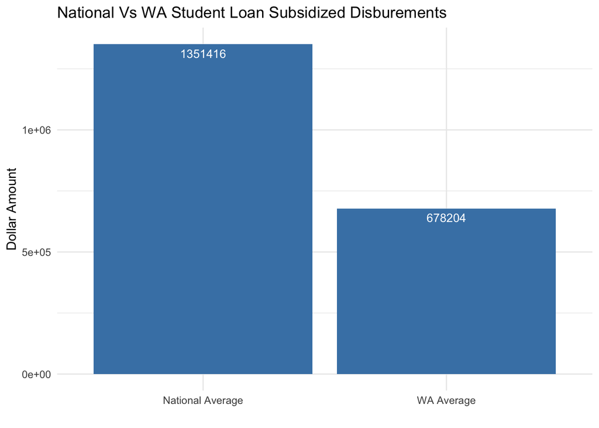

## Chart 2 - Recipients VS Amount Scatterplot

What we were interested in seeing with this chart was whether or not there was a relationship between how much money total a college receives in loans, and how many recipients they have. Each point is a college, the x axis is the number of recipients, and the y axis is the total dollar amount of loans given to that college. For example, the college plotted in the top right of the graph received about sixty million dollars in loans for about twenty five thousand loan recipients. What we found was that there is a strong linear relationship between the two variables. This is what we expected for the most part, as it makes sense that the more recipients, the more money. However, there are a few colleges that appear to deviate slightly from the norm, receiving less money for the amount of recipients than other colleges. It would be interesting to use something like plotly to create an interactive version and more closely examine these deviant cases.

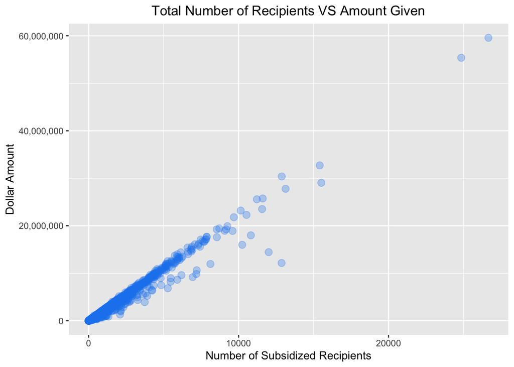

## Chart 3 Recipients numbers Vs School type

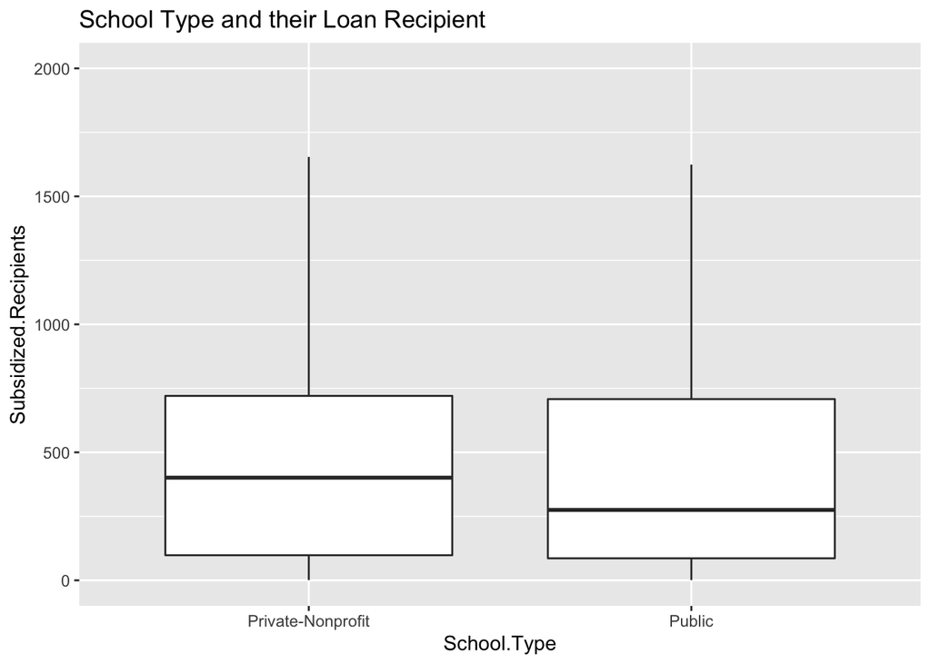